# Analysis of the Complete Block Design

October 7, 2021

## Announcements

- MP1 pre-approval due Friday 11:55p
- Office hours have changed!
  - Friday office hours 12:15p-3:00p
    - Please only sign up once per week
    - Appointment slots are open
- Where to get MP1 help
  - Post questions to #mini-project1 channel on Slack!
  - Direct message me on Slack.

## MP1 Pre-Approval

Your completed Qualtrics experiments are due for Pre-Approval by **Fri Oct 8 11:55p**.

1. Export your survey as a Word doc. Include the survey flow and any skip logic you used.
2. Upload the Word doc to Moodle.

I should be able to see any images you used or links to media. I’ll be paying particular attention to your consent form. It’s not unusual for me to ask for revisions before you launch your study.

## Next steps:

I will give you approval or revisions via Slack direct messages. Watch out for those!

Once you have completed any revisions and receive approval from me you can complete the following **checklist** and then share your anonymous survey link.

1. Proof read for errors.
2. Test (preview) your survey multiple times, creating fake data.
3. [Download the data](https://www.qualtrics.com/support/survey-platform/data-and-analysis-module/data/download-data/export-data-overview/) and make sure it makes sense.
4. Zero out the [randomization counts](https://www.qualtrics.com/support/survey-platform/survey-module/survey-flow/standard-elements/randomizer/#EditingCounts) in the survey flow.
5. [Delete](https://www.qualtrics.com/support/survey-platform/data-and-analysis-module/data/recorded-responses/#DeletingResponses) all of the fake responses.
6. [Upgrade](https://www.qualtrics.com/support/survey-platform/sp-administration/coupon-codes/#UpgradingasanExistingUser) your Qualtrics account with the code **SDS290Fall2021**.
7. Activate your survey.
8. Get the [anonymous survey link](https://www.qualtrics.com/support/survey-platform/distributions-module/distributions-overview/)!

## Agenda

1. Discuss your MP1 ideas in groups!
2. Complete Block design
- Diagnostic plots
- ANOVA

## MP1 discussions

- Groups of about four.
- Take turns describing your plan for MP1.
- Help your group mates think about what features of their stimuli they’ll want to try to control (“hold constant”) across conditions.

## Complete Block Design

- Experimental material are separated into groups (or reused) to create similar units
- Then each unit within a block is then is assigned one level of the factor of interest
- “Complete Block” means that every block x treatment combination is tested

## Inappropriate Insects

| treatment | tree1 | tree2 | tree3 | tree4 | tree5 |
| --- | --- | --- | --- | --- | --- |
| oil | 4 | 29 | 14 | 14 | 7 |
| spores | -4 | 29 | 4 | -2 | 11 |
| water | -9 | 18 | 10 | 9 | -6 |

Draw the factor diagram.

## MORE Design Terminology

- The two factors *Trees* and *Treatment* are **crossed**. This means that we collect data on all combinations of *Trees* and *Treatment*. A **cell** is a particular combination.
- **Main effect** refers to the effect for a single factor. For a block design there are two sets of main effects, for blocks and for treatments (e.g., *Trees* and *Treatment*).
- The two sets of main effects are called **additive** if each treatment adds or subtracts the same amount to the response variable for all blocks.
- A **factor of interest** is *Treatment*, which is directly related to the goal of the study. A **nuisance factor** is *Trees* which is included as a factor only because it is a source of variation and its inclusion will reduce the sum of squares for error (residuals).
- Typically, factors of interest are **fixed**, which means their effects are an unknown constant. Nuisance factors are **random**, which means their effects behave according to chance (the levels themselves are samples from a population).

## Side-by-side dotplot

We add our blocking factor as `color` and also as `group`.

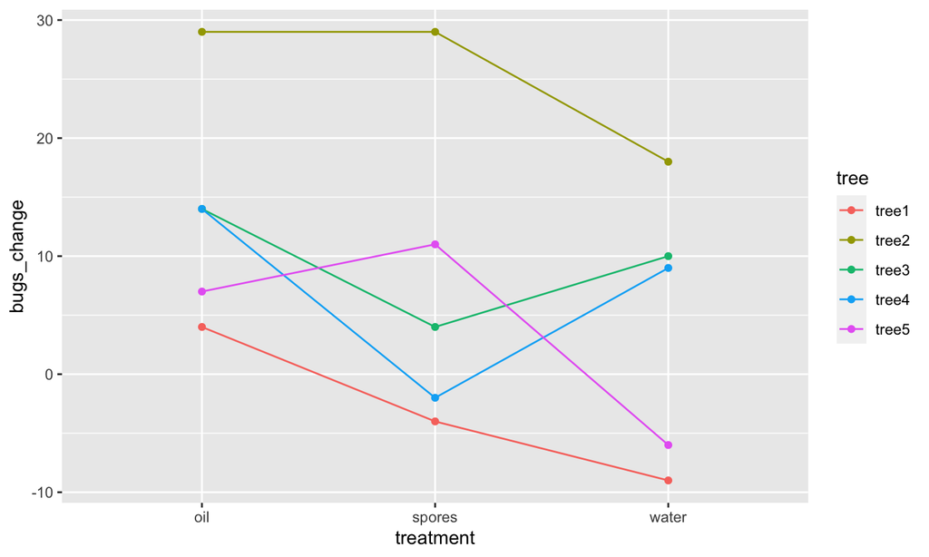

```r
qplot(x = treatment, y = bugs_change, color = tree, group = tree, data = mealybugs) +
  geom_line()
```

## Formal ANOVA for Complete Block Design

\[{y}_{ijk}={\mu}+{\tau}_{i}+{\beta}_{j}+{e}_{ijk}\]

| Source | SS | df | MS | F |
| --- | --- | --- | --- | --- |
| Treatment | \(\sum_{i=1}^{a}b(\bar{y}_{i.}-\bar{y}_{..})^{2}\) | \(a-1\) | \(\frac{{SS}_{T}}{{df}_{T}}\) | \(\frac{{MS}_{T}}{{MS}_{E}}\) |
| Blocks | \(\sum_{j=1}^{b}a(\bar{y}_{.j}-\bar{y}_{..})^{2}\) | \(b-1\) | \(\frac{{SS}_{B}}{{df}_{B}}\) | \(\frac{{MS}_{B}}{{MS}_{E}}\) |
| Error | \(\sum_{i=1}^{a}\sum_{j=1}^{b}({y}_{ij}-\bar{y}_{i.}-\bar{y}_{.j}+\bar{y}_{..})^{2}\) | \((a-1)(b-1)\) | \(\frac{{SS}_{E}}{{df}_{E}}\) |  |

## Data Analysis Structure

```r
mealybugs
```

```
##     tree treatment bugs_change
## 1  tree1     water          -9
## 2  tree1    spores          -4
## 3  tree1       oil           4
## 4  tree2     water          18
## 5  tree2    spores          29
## 6  tree2       oil          29
## 7  tree3     water          10
## 8  tree3    spores           4
## 9  tree3       oil          14
## 10 tree4     water           9
## 11 tree4    spores          -2
## 12 tree4       oil          14
## 13 tree5     water          -6
## 14 tree5    spores          11
## 15 tree5       oil           7
```

## Formal ANOVA

```r
mod <- lm(bugs_change ~ treatment + tree, data = mealybugs)

anova(mod)
```

```
## Analysis of Variance Table
##
## Response: bugs_change
##           Df  Sum Sq Mean Sq F value   Pr(>F)
## treatment  2  218.13  109.07  2.9963 0.106846
## tree       4 1316.40  329.10  9.0412 0.004603 **
## Residuals  8  291.20   36.40
## ---
## Signif. codes:  0 '***' 0.001 '**' 0.01 '*' 0.05 '.' 0.1 ' ' 1
```

Write a sentence interpreting the results of the F-test for treatment and a sentence interpreting the F-test for tree in the context of the problem.

## Formal ANOVA

```r
mod <- lm(bugs_change ~ treatment + tree, data = mealybugs)

anova(mod)
```

```
## Analysis of Variance Table
##
## Response: bugs_change
##           Df  Sum Sq Mean Sq F value   Pr(>F)
## treatment  2  218.13  109.07  2.9963 0.106846
## tree       4 1316.40  329.10  9.0412 0.004603 **
## Residuals  8  291.20   36.40
## ---
## Signif. codes:  0 '***' 0.001 '**' 0.01 '*' 0.05 '.' 0.1 ' ' 1
```

There are no statistically significant differences in the reduction in mealy bugs between the three treatment conditions, \(F(2, 8) = 3.00\), \(p = .107\). There are significant differences in the reduction in mealy bugs across trees, however, \(F(4, 8) = 9.04\), \(p = .005\). That is, some trees improved more than other trees.

## Informal Analysis Structure

```r
mealybugs_wide <- mealybugs %>%
  spread(treatment, bugs_change)
```

## Anscombe Block Plots

- Scatterplots of two levels of the factor of interest.
- Used for
  - exploring the data, and
  - assessing the **additivity (A)** condition.

## Scatterplots

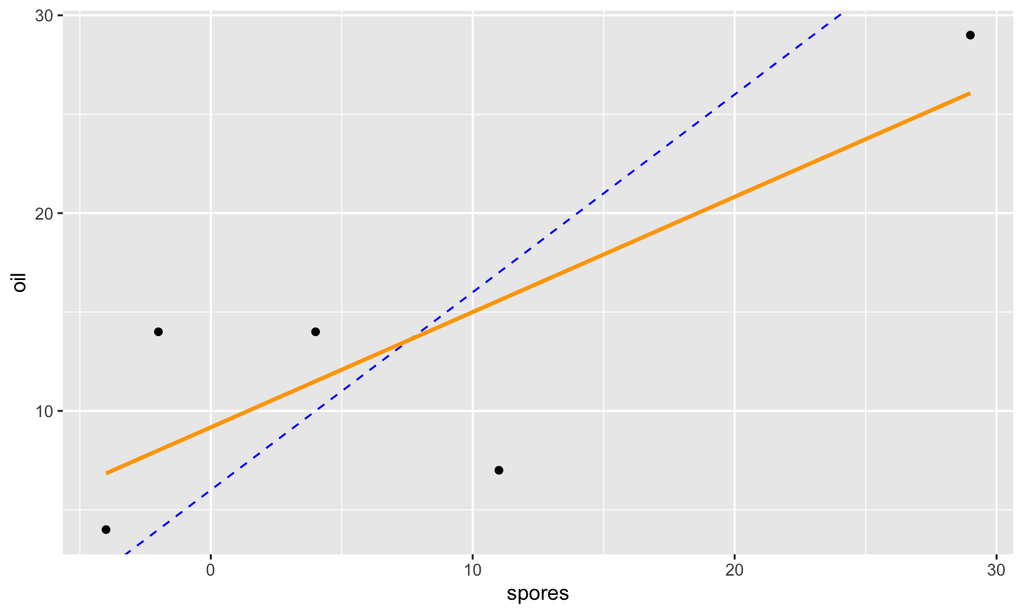

```r
qplot(x = spores, y = oil, data = mealybugs_wide) +
  geom_abline(intercept = 13.6-7.6, slope = 1, color = "blue", linetype = 2) +
  geom_smooth(method = "lm", se = 0, color = "orange")
```

## Scatterplots

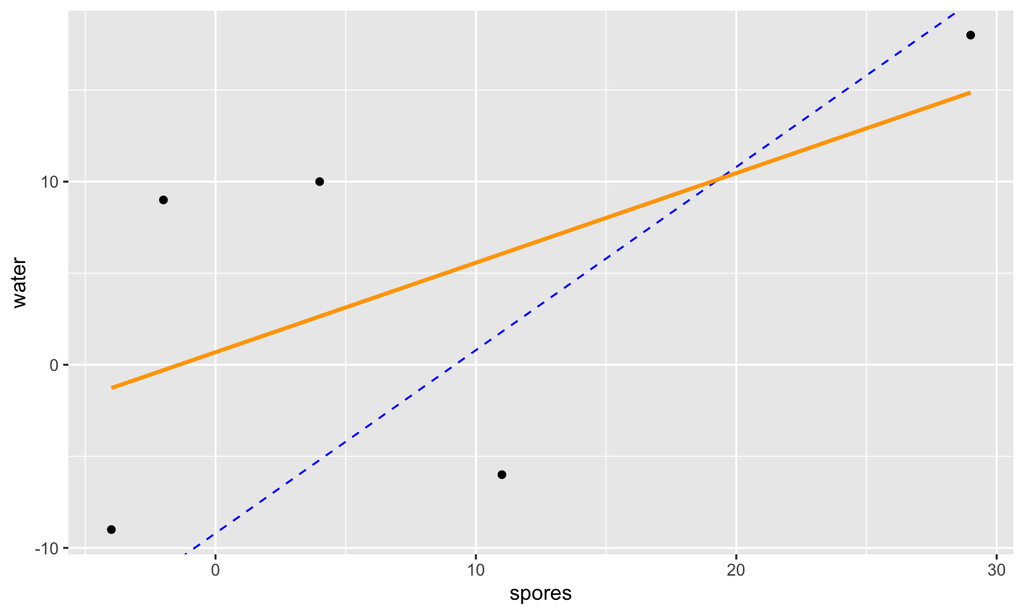

```r
qplot(x = spores, y = water, data = mealybugs_wide) +
  geom_abline(intercept = 4.4 - 13.6, slope = 1, color = "blue", linetype = 2) +
  geom_smooth(method = "lm", se = 0, color = "orange")
```

## Scatterplots

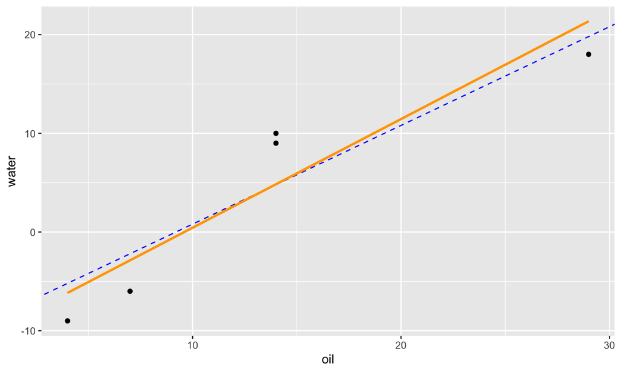

```r
qplot(x = oil, y = water, data = mealybugs_wide) +
  geom_abline(intercept = 4.4 - 13.6, slope = 1, color = "blue", linetype = 2) +
  geom_smooth(method = "lm", se = 0, color = "orange")
```